# Software tutorial 3

Reproducible research pipelines with R and Quarto

Valentin Klotzbücher

November 13, 2024

# Tutorial 3

**Live-Coding Topics**:

- Merging, cleaning, and reshaping data
- Loading and saving data formats
- Working with geospatial data in R
- Creating static and dynamic maps

## Data

We’ll use:

- Migration data (Niva et al. 2023)
- Conflict event data from [Uppsala Conflict Data Program (UCDP)](https://ucdp.uu.se) (Sundberg and Melander 2013; Davies et al. 2024)

## Plot maps

- Produce a basic map of the country borders included with the migration data
- Plot the migration data on different levels

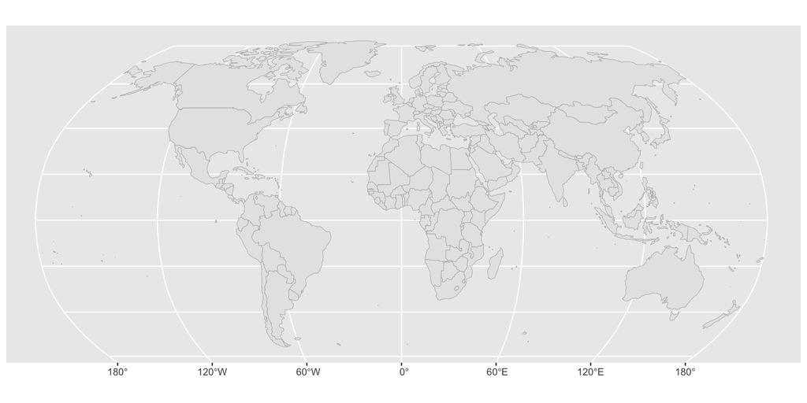

Figure 1: Basic country-level map

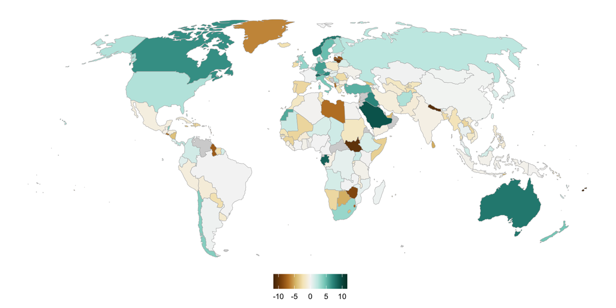

Figure 2: Net migration in 2014, country-level

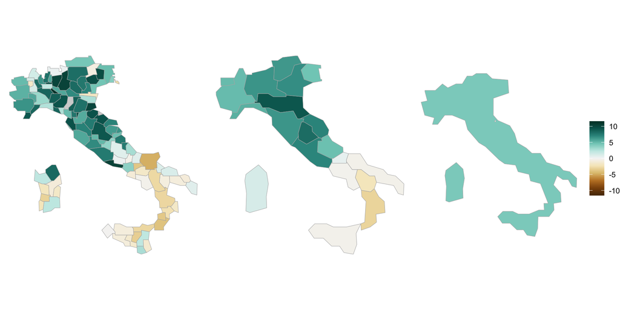

Figure 3: Net migration in Italy 2014, regional and communal level

### Load UCDP

### Loading times and file size for different formats (try others)

- CSV with `read.csv`: 14.1 seconds, 255.93 MB
- Parquet with `read_parquet` from the `arrow` package: 0.6 seconds, 41.87 MB

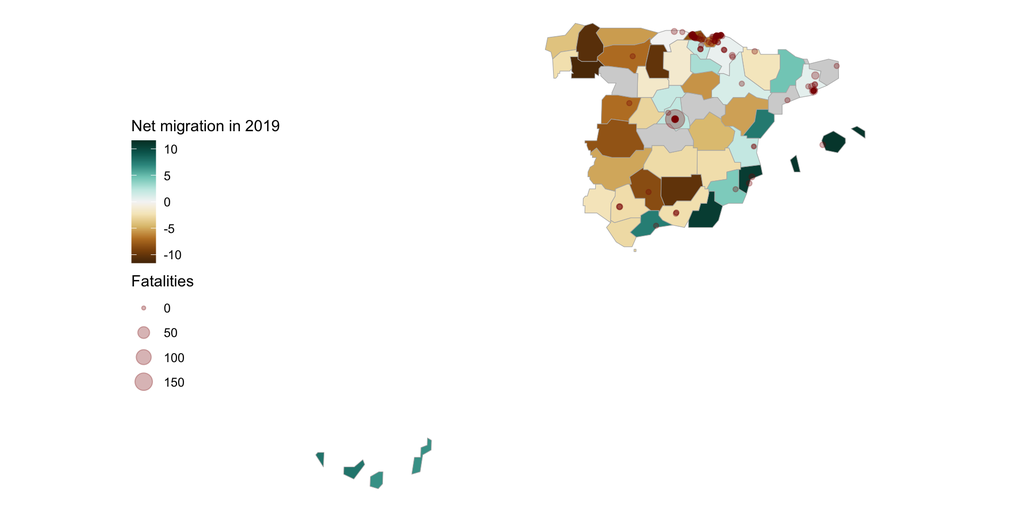

Figure 4: Net migration across Spain in 2019 and past conflict events (1989-2019, size indicates the estimated number of deaths)

[interactive chart not shown]

Figure 5: Interactive map of conflict events

### Merge Data: Country Name Matching

Objective: Match conflict event data (UCDP) to migration and map data using country names.

- Aggregate UCDP Data conflict event data by country.
- Standardize Country Names, remove inconsistencies.
- Perform the Merge: Use left_join() to merge the conflict data with the migration and map data based on the standardized country names.
- Inspect the `country` column in both datasets.

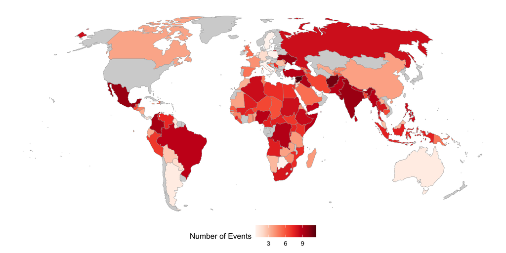

### Fuzzy matching

Does not really help much here, but can be very useful in other cases:

Use approximate (fuzzy) matching to align country names when there are minor differences (e.g., “US” vs. “USA”).

- Identify Unmatched Names: Check which country names in the UCDP data did not match with the map data.
- Apply Fuzzy Matching: Use string distance measures to find closest matches.
- Review and Adjust Matches: Manually inspect the results to see potential matches

### Spatial Join: Using Geometries for Matching

Match conflict events to countries based on their spatial locations instead of country names.

- Prepare Spatial Data: Ensure both the UCDP conflict events and map data are in the same coordinate reference system (CRS).
- Perform Spatial Join: Use st_intersects() or similar spatial functions to assign conflict events to the country polygons they fall within.

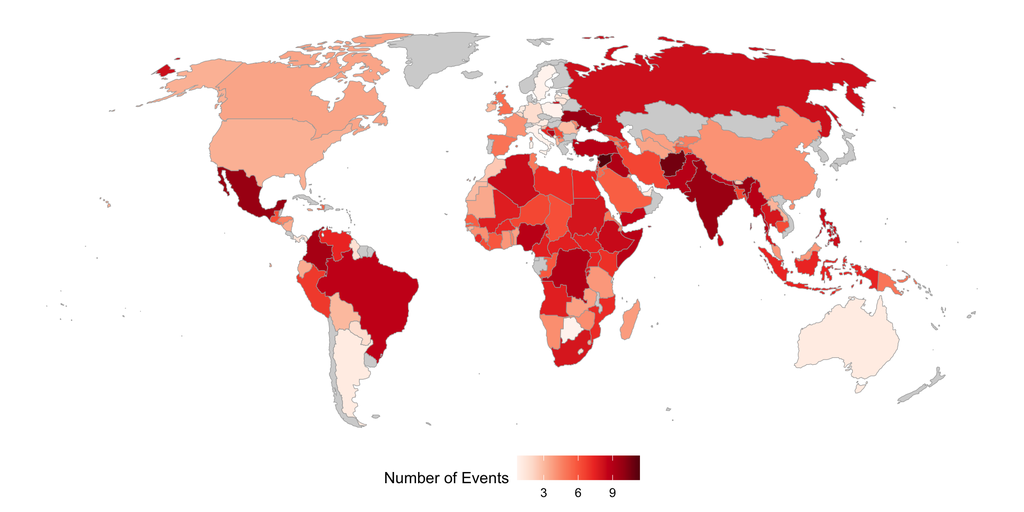

## Comparison of Merging Approaches

| **Approach** | **Use Case** | **Challenges** |
| --- | --- | --- |
| **Name Matching** | When datasets have consistent country names | Requires manual cleaning of names |
| **Fuzzy Matching** | When names are similar but not identical | May produce inaccurate matches |
| **Spatial Join** | When spatial data is available | Computationally intensive for large datasets |

## (Take-home) Assignment

- Start a new project for RevealJS (optional also PDF) slides
- Make a static map of subnational migration patterns in “your” country based on Niva et al. (2023)
- Add UCDP GED conflict event data to the map
- Add an interactive `leaflet` map
- Calculate aggregates for conflict events on adm1-level and merge the result with the migration data. Make sure that all regions are matched correctly.
- Produce a matched panel data set on adm2-year level (perform a spatial join if necessary)
- Adjust the RevealJS slides according to your preferences (use custom themes or modify the `custom.scss` file)
- Submit your HTML file and the qmd file used to generate it until Novemer 20, 2024 (email/ILIAS).

*References specifically for RevealJS slides*

- [Quarto manual](https://quarto.org/docs/presentations/revealjs/)
- [Sophie Lee TWIL](https://scubed.rbind.io/blog/twil_quarto_pres/)
- [Emil Hvitfeld on making Themes](https://github.com/EmilHvitfeldt/quarto-revealjs-seasons)

### References

Davies, Shawn, Garoun Engström, Therese Pettersson, and Magnus Öberg, “[Organized violence 1989–2023, and the prevalence of organized crime groups](https://doi.org/10.1177/00223433241262912),” *Journal of Peace Research*, 61 (2024), 673–693.

Niva, Venla, Alexander Horton, Vili Virkki, Matias Heino, Maria Kosonen, Marko Kallio, Pekka Kinnunen, Guy J Abel, Raya Muttarak, Maija Taka, and others, “[World’s human migration patterns in 2000–2019 unveiled by high-resolution data](https://doi.org/10.1038/s41562-023-01689-4),” *Nature Human Behaviour*, 7 (2023), 2023–2037.

Sundberg, Ralph, and Erik Melander, “[Introducing the UCDP georeferenced event dataset](https://doi.org/10.1177/0022343313484347),” *Journal of peace research*, 50 (2013), 523–532.